# Time_Series_Analysis _2

```python
# Import necessary libraries
import pandas as pd
import numpy as np

# # Load the dataset
df = pd.read_csv('bitcoin_price.csv', parse_dates=['Date'], index_col='Date')

# The parse_dates and index_col parameters in the pd.read_csv() function have specific roles,
# especially useful in time series analysis:

# parse_dates
# The parse_dates parameter is used to specify which columns should be parsed as dates.
# This means that the data in these columns will be converted from string format to datetime objects,
# which makes it easier to perform time-based operations.

# index_col
# The index_col parameter is used to specify which column should be used as the index of the DataFrame.
#  The index of a DataFrame is the label of each row, which can be particularly useful
# in time series analysis to have the dates as the index.

# Reset index to get 'Date' as a column
df_reset = df.reset_index()


# Remove commas and convert columns to float
columns_to_convert = ['Price', 'Open', 'High', 'Low']
for column in columns_to_convert:
    df[column] = df[column].str.replace(',', '').astype(float)


# Preprocess 'Change %' column
df['Change %'] = df['Change %'].str.replace('%', '').astype(float)
# df = pd.read_csv('bitcoin_price.csv'
#                 #  , parse_dates=['Date']
#                 # , index_col='Date'
#                    )
df.head()
```

| Date | Price | Open | High | Low | Vol. | Change % |
| --- | --- | --- | --- | --- | --- | --- |
| 2021-08-24 | 48846.3 | 49532.5 | 49847.4 | 48812.4 | 59.89K | -1.40 |
| 2021-08-23 | 49539.7 | 49255.4 | 50498.8 | 49038.6 | 75.37K | 0.58 |
| 2021-08-22 | 49254.5 | 48870.4 | 49480.3 | 48151.0 | 49.32K | 0.77 |
| 2021-08-21 | 48875.8 | 49330.0 | 49719.1 | 48293.5 | 18.20K | -0.91 |
| 2021-08-20 | 49324.0 | 46756.7 | 49343.3 | 46646.8 | 83.19K | 5.49 |

```python
df.columns
```

```
Index(['Price', 'Open', 'High', 'Low', 'Vol.', 'Change %'], dtype='object')
```

```python
# # Manually rename the columns if necessary (if 'Date' is not recognized)
# df.columns = ['Date', 'Price', 'Open', 'High', 'Low', 'Vol.', 'Change %']
# df.head()
```

```python
# Import necessary libraries
import pandas as pd
import numpy as np
from statsmodels.tsa.stattools import adfuller
from statsmodels.tsa.seasonal import seasonal_decompose
from statsmodels.tsa.arima.model import ARIMA
from statsmodels.tsa.statespace.sarimax import SARIMAX
from statsmodels.tsa.holtwinters import SimpleExpSmoothing, Holt, ExponentialSmoothing
from sklearn.metrics import mean_absolute_error, mean_squared_error
from math import sqrt
# !pip install prophet
from prophet import Prophet
```

```python
# Load the dataset
df = pd.read_csv('bitcoin_price.csv', parse_dates=['Date'], index_col='Date')


# Convert 'Price' column to float type
df['Price'] = df['Price'].str.replace(',', '').astype(float)

# Check for stationarity
result = adfuller(df['Price'])
print('ADF Statistic: %f' % result[0])
print('p-value: %f' % result[1])

# Apply differencing
df['Price_diff'] = df['Price'] - df['Price'].shift(1)
```

```
ADF Statistic: -2.687474
p-value: 0.076231
```

The `adfuller` function from the `statsmodels` library returns a tuple of results, and each element of this tuple provides specific information about the Augmented Dickey-Fuller (ADF) test. The indices 0 and 1 are used to access specific elements within this tuple. Here’s a breakdown of what each element in the tuple represents:

1. **ADF Statistic (result[0])**: This is the test statistic value. The ADF statistic is used to test the null hypothesis that a unit root is present in a time series sample. A more negative value indicates a stronger rejection of the null hypothesis.
2. **p-value (result[1])**: This is the p-value associated with the test statistic. It helps to determine the significance of the results. A lower p-value (typically < 0.05) indicates that you can reject the null hypothesis, suggesting that the time series is stationary.

Here’s the full structure of the tuple returned by `adfuller`:

1. `result[0]`: The ADF test statistic.
2. `result[1]`: The p-value.
3. `result[2]`: The number of lags used in the test.
4. `result[3]`: The number of observations used for the ADF regression and calculation of the critical values.
5. `result[4]`: A dictionary containing the critical values for the test statistic at the 1%, 5%, and 10% levels.
6. `result[5]`: The maximized information criterion if autolag is not None.

### Explanation of Each Element

- **ADF Statistic (result[0])**: Indicates how strongly the null hypothesis can be rejected.
- **p-value (result[1])**: Shows the probability of observing the test results under the null hypothesis.
- **Number of lags used (result[2])**: The number of lagged differences included in the test.
- **Number of observations used (result[3])**: The sample size used in the ADF regression.
- **Critical values (result[4])**: Benchmark values to compare the ADF statistic against to determine significance.
- **Maximized Information Criterion (result[5])**: Only provided if `autolag` is not None, used to choose the number of lags.

Using the indices 0 and 1 allows you to directly access the ADF Statistic and the p-value, which are typically the most important results for determining whether a time series is stationary.

Let's break down the statement: "The ADF statistic is used to test the null hypothesis that a unit root is present in a time series sample. A more negative value indicates a stronger rejection of the null hypothesis."

### Augmented Dickey-Fuller (ADF) Test

The Augmented Dickey-Fuller (ADF) test is a statistical test used to determine whether a time series is stationary or has a unit root. Stationarity is a key property in time series analysis, indicating that the statistical properties of the series (mean, variance) do not change over time.

### Null Hypothesis and Alternative Hypothesis

1. **Null Hypothesis (H0)**: The time series has a unit root, meaning it is non-stationary. It may exhibit some time-dependent structure.
2. **Alternative Hypothesis (H1)**: The time series does not have a unit root, meaning it is stationary. Its properties do not depend on the time at which the series is observed.

### ADF Statistic

The ADF statistic is a number calculated from your data that is used to test the null hypothesis. Here's what it means:

- **ADF Statistic**: This is the test statistic calculated by the ADF test.

### Interpreting the ADF Statistic

- **More Negative Value**: The ADF statistic is compared to critical values from the ADF test table. If the ADF statistic is more negative than the critical value, it suggests that the null hypothesis can be rejected.
- **Less Negative or Positive Value**: If the ADF statistic is not very negative, it suggests that you cannot reject the null hypothesis.

### Why a More Negative Value?

- The ADF test checks for the presence of a unit root by estimating a regression model. The test statistic essentially measures how strongly the series is predicted by its lagged values plus a deterministic trend.
- A very negative ADF statistic indicates that the time series is less likely to be explained by a random walk (a characteristic of non-stationary series with a unit root) and more likely to be stationary.

### Example for Clarity

Suppose you run an ADF test on a time series and get the following results:

- **ADF Statistic**: -4.2
- **Critical Value at 5% level**: -2.9
- **p-value**: 0.01

Interpretation:

1. **Compare ADF Statistic to Critical Value**: -4.2 is more negative than -2.9.
2. **Reject the Null Hypothesis**: Since -4.2 < -2.9, you reject the null hypothesis at the 5% significance level.
3. **Conclusion**: The time series is stationary (does not have a unit root).

### Summary

- The ADF statistic helps determine if a time series is stationary.
- The null hypothesis is that the series has a unit root (non-stationary).
- A more negative ADF statistic indicates stronger evidence against the null hypothesis.
- If the ADF statistic is more negative than the critical value, you reject the null hypothesis and conclude that the series is stationary.

```python
df.head()
```

| Date | Price | Open | High | Low | Vol. | Change % | Price_diff |
| --- | --- | --- | --- | --- | --- | --- | --- |
| 2021-08-24 | 48846.3 | 49,532.5 | 49,847.4 | 48,812.4 | 59.89K | -1.40% | NaN |
| 2021-08-23 | 49539.7 | 49,255.4 | 50,498.8 | 49,038.6 | 75.37K | 0.58% | 693.4 |
| 2021-08-22 | 49254.5 | 48,870.4 | 49,480.3 | 48,151.0 | 49.32K | 0.77% | -285.2 |
| 2021-08-21 | 48875.8 | 49,330.0 | 49,719.1 | 48,293.5 | 18.20K | -0.91% | -378.7 |
| 2021-08-20 | 49324.0 | 46,756.7 | 49,343.3 | 46,646.8 | 83.19K | 5.49% | 448.2 |

# SimpleExpSmoothing

In the code `SimpleExpSmoothing(data).fit(smoothing_level=0.2, optimized=False)`, the `smoothing_level` argument controls the weight given to past data points in the `SimpleExpSmoothing` model. It's also sometimes referred to as alpha (α).

Here's a breakdown of its effect:

- **Higher smoothing_level (closer to 1):** Places more emphasis on the **most recent** data point. This leads to forecasts that are more reactive to recent changes but may be more susceptible to noise or outliers.
- **Lower smoothing_level (closer to 0):** Places more emphasis on **past data points**, resulting in smoother forecasts that are less sensitive to recent fluctuations but may be slower to adapt to trends.

Choosing the right `smoothing_level` depends on the characteristics of your data. If your data has frequent fluctuations but a clear underlying trend, you might use a value closer to 1. Conversely, for data with slow changes and minimal noise, a value closer to 0 might be appropriate.

Here are some additional points to consider:

- The default value for `smoothing_level` in some libraries might be `None`, which often triggers estimation of the parameter based on the data.
- Experimenting with different `smoothing_level` values can help you find the best fit for your specific time series data.

```python
# Apply ARIMA model
model = ARIMA(df['Price'], order=(5,1,0))
model_fit = model.fit()

# Apply SARIMA model
model = SARIMAX(df['Price'], order=(1, 1, 1), seasonal_order=(1, 1, 1, 12))
model_fit = model.fit(disp=False)

# Apply Simple Exponential Smoothing
model = SimpleExpSmoothing(df['Price'])
model_fit = model.fit()

# In simple exponential smoothing has a parameter known as alpha which defines how much weightage
# we want to give to recent observation. the smoothing_level argument or alpha

# Apply Holt's Linear Trend Method
model = Holt(df['Price'])
model_fit = model.fit()

# Apply Holt-Winters Method
model = ExponentialSmoothing(df['Price'])
model_fit = model.fit()
```

[output not shown]

In ARIMA models, p, d, and q represent different aspects of how the model captures patterns in your time series data:

- **p (AutoRegressive order):** This parameter signifies the number of past values of the time series that are included in the model to predict the current value. Essentially, it considers the impact of the past **p** observations on the present value.
- **d (Differencing order):** This value indicates the number of times the data needs to be differenced to achieve stationarity. Stationarity means the statistical properties of the data (like mean and variance) remain constant over time. Differencing removes trends or seasonality that might prevent accurate forecasting.
- **q (Moving Average order):** This parameter represents the number of past forecast errors included in the model. Forecast errors are the differences between the predicted values and the actual values. Including past errors helps account for randomness in the data.

In the code you provided:

- **p = 5:** The model considers the influence of the past 5 data points on the current prediction.
- **d = 1:** The data is differenced once to achieve stationarity.
- **q = 0:** The model doesn't incorporate past forecast errors (i.e., no moving average component). This suggests the model assumes the errors are random and not correlated with past errors.

It's important to note that finding the optimal values for p, d, and q often involves an iterative process of analysis and evaluation. There are techniques like examining autocorrelation plots and partial autocorrelation plots to identify these parameters effectively.

```python
# # Calculate error metrics
# y_true = df['Price'].values
# y_pred = model_fit.fittedvalues.values
# mae = mean_absolute_error(y_true, y_pred)
# mse = mean_squared_error(y_true, y_pred)
# rmse = sqrt(mse)
# print('MAE: %f' % mae)
# print('MSE: %f' % mse)
# print('RMSE: %f' % rmse)

# # Create a new dataframe for Prophet model
# df_prophet = df[['Date', 'Price']].copy()
# df_prophet.columns = ['ds', 'y']  # rename the columns for Prophet compatibility

# # Use Prophet for forecasting
# model = Prophet()
# model.fit(df_prophet)
# future = model.make_future_dataframe(periods=365)
# forecast = model.predict(future)
```

```python
# # Import necessary libraries
# import pandas as pd
# import numpy as np
# from math import sqrt
# from sklearn.metrics import mean_absolute_error, mean_squared_error
# from fbprophet import Prophet

# # Load the dataset
# df = pd.read_csv('bitcoin_price.csv', parse_dates=['Date'], index_col='Date')

# # Remove commas and convert 'Price' column to float
# df['Price'] = df['Price'].str.replace(',', '').astype(float)

# # Fit an ARIMA model (assuming model_fit is already defined)
# # model_fit = ...

# Calculate error metrics
y_true = df['Price'].values
y_pred = model_fit.fittedvalues.values
mae = mean_absolute_error(y_true, y_pred)
mse = mean_squared_error(y_true, y_pred)
rmse = sqrt(mse)
print('MAE: %f' % mae)
print('MSE: %f' % mse)
print('RMSE: %f' % rmse)

# # Reset index to get 'Date' as a column
df_reset = df.reset_index()

# Create a new dataframe for Prophet model
df_prophet = df_reset[['Date', 'Price']].copy()
df_prophet.columns = ['ds', 'y']  # rename the columns for Prophet compatibility

# Use Prophet for forecasting
model = Prophet()
model.fit(df_prophet)
future = model.make_future_dataframe(periods=365)
forecast = model.predict(future)

# Display the forecast
forecast[['ds', 'yhat', 'yhat_lower', 'yhat_upper']].tail()
```

```
MAE: 166.976514
MSE: 273574.682871
RMSE: 523.043672
```

```
06:30:15 - cmdstanpy - INFO - Chain [1] start processing
06:30:16 - cmdstanpy - INFO - Chain [1] done processing
```

|  | ds | yhat | yhat_lower | yhat_upper |
| --- | --- | --- | --- | --- |
| 4416 | 2022-08-20 | 58672.786721 | 52361.334269 | 65480.110080 |
| 4417 | 2022-08-21 | 58667.038648 | 51766.319411 | 65450.758027 |
| 4418 | 2022-08-22 | 58685.324498 | 52365.566014 | 65622.583610 |
| 4419 | 2022-08-23 | 58678.516579 | 51767.290705 | 65071.469479 |
| 4420 | 2022-08-24 | 58669.804229 | 53113.162438 | 65785.058420 |

**Overall Interpretation:**

- **Prophet** is a forecasting model specifically designed for time series with daily seasonality. It might not be ideal for capturing high-frequency intraday movements in Bitcoin price.
- The quality of any forecast depends on the quality of the historical data used to train the model.
- Time series forecasting is inherently uncertain, and the model's predictions are just that - predictions, not guarantees of future prices.

```python
# Import necessary libraries
import pandas as pd
import numpy as np
import matplotlib.pyplot as plt
import seaborn as sns
from statsmodels.tsa.stattools import adfuller, acf, pacf
from statsmodels.tsa.seasonal import seasonal_decompose
```

```python
df.info()
```

```
<class 'pandas.core.frame.DataFrame'>
DatetimeIndex: 4056 entries, 2021-08-24 to 2010-07-18
Data columns (total 7 columns):
 #   Column      Non-Null Count  Dtype
---  ------      --------------  -----
 0   Price       4056 non-null   float64
 1   Open        4056 non-null   object
 2   High        4056 non-null   object
 3   Low         4056 non-null   object
 4   Vol.        4056 non-null   object
 5   Change %    4056 non-null   object
 6   Price_diff  4055 non-null   float64
dtypes: float64(2), object(5)
memory usage: 253.5+ KB
```

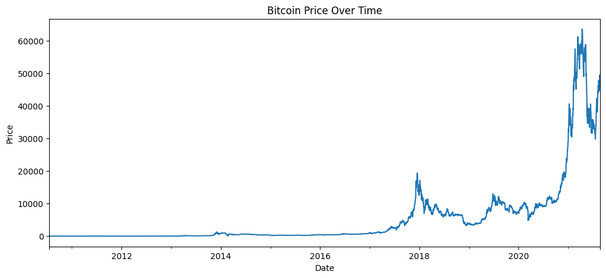

```python
# Create a line plot of the time series data
df['Price'].plot(figsize=(12, 5))
df['Price']
plt.title('Bitcoin Price Over Time')
plt.ylabel('Price')
plt.show()
```

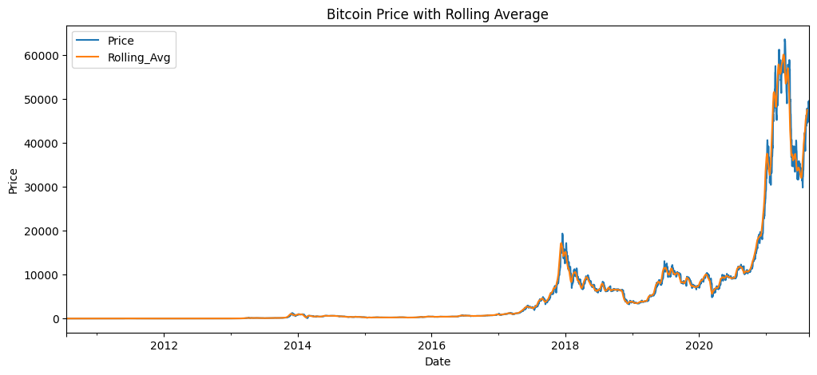

```python
# Calculate and plot the rolling average
df['Rolling_Avg'] = df['Price'].rolling(window=12).mean()
df[['Price', 'Rolling_Avg']].plot(figsize=(12, 5))
plt.title('Bitcoin Price with Rolling Average')
plt.ylabel('Price')
plt.show()
```

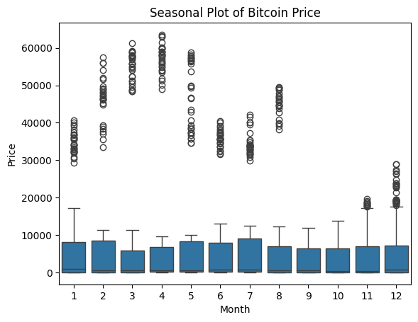

```python
# Ensure the index is in datetime format
df.index = pd.to_datetime(df.index)

# Create a new column 'Month' in your dataframe
df['Month'] = df.index.month

# Now you can create your boxplot
sns.boxplot(x='Month', y='Price', data=df)
plt.title('Seasonal Plot of Bitcoin Price')
plt.xlabel('Month')
plt.ylabel('Price')
plt.show()
```

```python
# # Create autocorrelation and partial autocorrelation plots
# plot_acf(df['Price'], lags=50)
# plot_pacf(df['Price'], lags=50)
```

```python
# Perform seasonal decomposition
decomposition = seasonal_decompose(df['Price'])
```

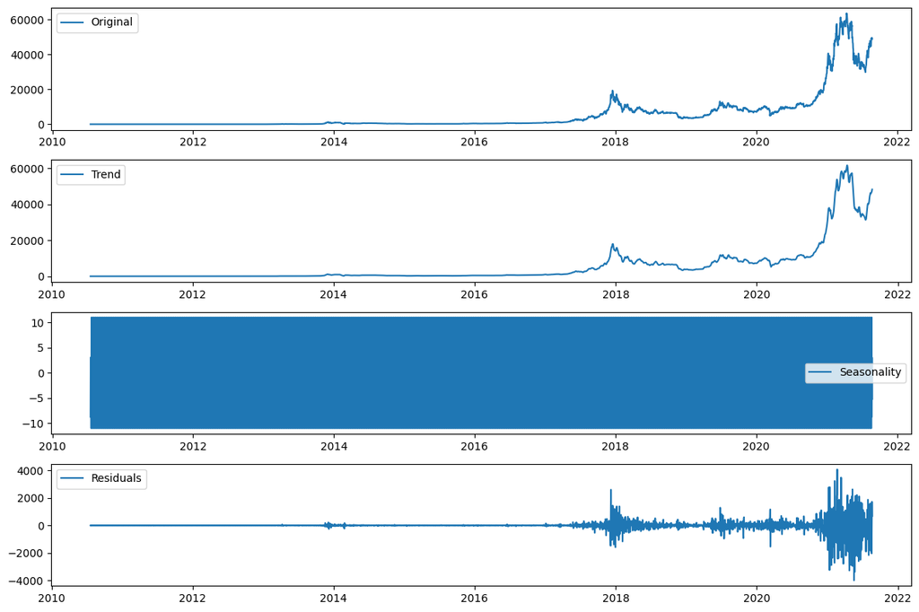

```python
# Plot the original time series, trend, seasonality, and residuals
plt.figure(figsize=(12,8))
plt.subplot(411)
plt.plot(df['Price'], label='Original')
plt.legend(loc='best')
plt.subplot(412)
plt.plot(decomposition.trend, label='Trend')
plt.legend(loc='best')
plt.subplot(413)
plt.plot(decomposition.seasonal,label='Seasonality')
plt.legend(loc='best')
plt.subplot(414)
plt.plot(decomposition.resid, label='Residuals')
plt.legend(loc='best')
plt.tight_layout()
```

[figure not shown]

```python
#1.ARIMA Modeling:

import pandas as pd
import matplotlib.pyplot as plt
from statsmodels.tsa.arima.model import ARIMA

# Load the Bitcoin price data
data = pd.read_csv('bitcoin_price.csv')

# Convert the 'Date' column to datetime
data['Date'] = pd.to_datetime(data['Date'])

# Set the 'Date' column as the index
data.set_index('Date', inplace=True)

# Plot the Bitcoin prices
plt.plot(data['Price'])
plt.xlabel('Date')
plt.ylabel('Price')
plt.title('Bitcoin Price Data')
plt.show()
```

[figure not shown]

```python
# Fit the ARIMA model
# Convert 'Price' column to numeric type
data['Price'] = pd.to_numeric(data['Price'], errors='coerce')

model = ARIMA(data['Price'], order=(1, 1, 1))
model_fit = model.fit()

# Generate in-sample forecasts
forecast_arima = model_fit.predict(start=1, end=len(data), typ='levels')

# Plot the original data and the forecasts
plt.plot(data['Price'], label='Actual')
plt.plot(forecast, label='Forecast')
plt.xlabel('Date')
plt.ylabel('Price')
plt.title('ARIMA Forecasting')
plt.legend()
plt.show();
```

[output not shown]

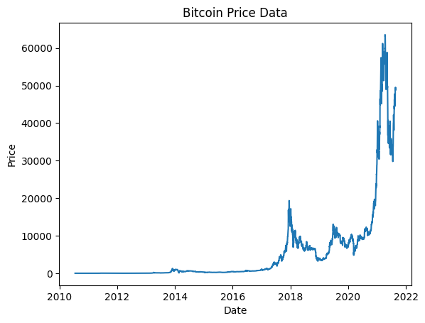

```python
#2. SARIMA Modeling:


import pandas as pd
import matplotlib.pyplot as plt
from statsmodels.tsa.statespace.sarimax import SARIMAX

# Load the Bitcoin price data
data = pd.read_csv('bitcoin_price.csv')

# Convert 'Price' column to float type
data['Price'] = data['Price'].str.replace(',', '').astype(float)

# Convert the 'Date' column to datetime
data['Date'] = pd.to_datetime(data['Date'])

# Set the 'Date' column as the index
data.set_index('Date', inplace=True)

# Generate in-sample forecasts
# Fit the SARIMA model
model = SARIMAX(data['Price'], order=(1, 1, 1), seasonal_order=(0, 1, 1, 12))
model_fit = model.fit()

# Generate in-sample forecasts
forecast_sarima = model_fit.predict(start=1, end=len(data), typ='levels')


# Plot the Bitcoin prices
plt.plot(data['Price'])
plt.xlabel('Date')
plt.ylabel('Price')
plt.title('Bitcoin Price Data')
plt.show()
```

```
06:30:48 - cmdstanpy - INFO - Chain [1] start processing
06:30:49 - cmdstanpy - INFO - Chain [1] done processing
```

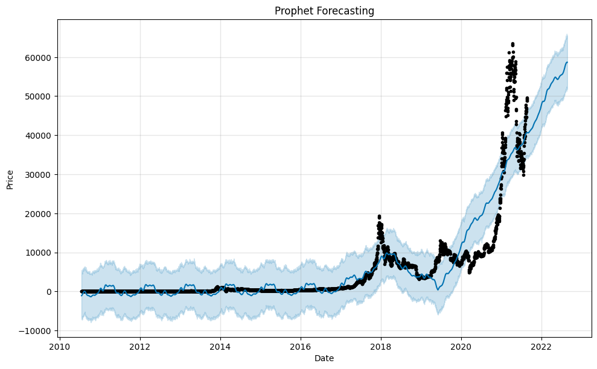

```python
#3.Prophet Modeling:

import pandas as pd
import matplotlib.pyplot as plt
from prophet import Prophet

# Load the Bitcoin price data
data = pd.read_csv('bitcoin_price.csv')

data_prophet = data.copy()

# Rename the columns for Prophet
data_prophet = data_prophet.rename(columns={'Date': 'ds', 'Price': 'y'})

# Convert 'Price' column to float type
data_prophet['y'] = data_prophet['y'].str.replace(',', '').astype(float)

# Create a Prophet model
model = Prophet()

# Fit the model to the Bitcoin price data
model.fit(data_prophet)

# Generate in-sample forecasts
future = model.make_future_dataframe(periods=365)
forecast_prophet = model.predict(future)

# Plot the forecasted values
model.plot(forecast_prophet, xlabel='Date', ylabel='Price')
plt.title('Prophet Forecasting')
plt.show()
```

```python
# Load the Bitcoin price data
data = pd.read_csv('bitcoin_price.csv')

# Convert 'Price' column to float type
data['Price'] = data['Price'].str.replace(',', '').astype(float)

# Convert the 'Date' column to datetime
data['Date'] = pd.to_datetime(data['Date'])

# Set the 'Date' column as the index
data.set_index('Date', inplace=True)
# Calculate MAE and RMSE for ARIMA model
mae_arima = mean_absolute_error(data['Price'], forecast_arima)
rmse_arima = sqrt(mean_squared_error(data['Price'], forecast_arima))
print("ARIMA Model - MAE: ", mae_arima)
print("ARIMA Model - RMSE: ", rmse_arima)
```

```
ARIMA Model - MAE:  5261.170695703572
ARIMA Model - RMSE:  12094.486653892161
```

```python
# Calculate MAE and RMSE for Prophet model
forecast_prophet_matched = forecast_prophet['yhat'][:len(data_prophet)]
mae_prophet = mean_absolute_error(data_prophet['y'], forecast_prophet_matched)
rmse_prophet = sqrt(mean_squared_error(data_prophet['y'], forecast_prophet_matched))
print("Prophet Model - MAE: ", mae_prophet)
print("Prophet Model - RMSE: ", rmse_prophet)
```

```
Prophet Model - MAE:  10585.087284878724
Prophet Model - RMSE:  16359.248864069026
```

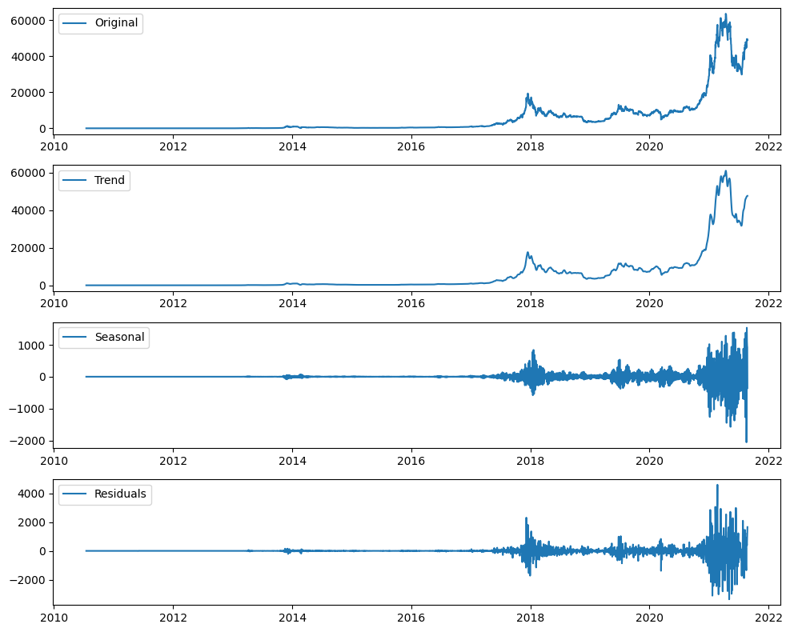

```python
# Seasonality Decomposition (STL):
import pandas as pd
import matplotlib.pyplot as plt
from statsmodels.tsa.seasonal import STL

# Load the Bitcoin price data
data = pd.read_csv('bitcoin_price.csv')

# Convert 'Price' column to float type
data['Price'] = data['Price'].str.replace(',', '').astype(float)

# Convert the 'Date' column to datetime
data['Date'] = pd.to_datetime(data['Date'])

# Set the 'Date' column as the index
data.set_index('Date', inplace=True)

# Perform STL decomposition
decomposition = STL(data['Price'])
result = decomposition.fit()

# Plot the decomposition components
fig, (ax1, ax2, ax3, ax4) = plt.subplots(4, 1, figsize=(10, 8))
ax1.plot(data['Price'], label='Original')
ax1.legend()
ax2.plot(result.trend, label='Trend')
ax2.legend()
ax3.plot(result.seasonal, label='Seasonal')
ax3.legend()
ax4.plot(result.resid, label='Residuals')
ax4.legend()
plt.tight_layout()
plt.show()
```

```python
# Anomaly Detection (Z-Score)
import pandas as pd
import numpy as np

# Load the Bitcoin price data
data = pd.read_csv('bitcoin_price.csv')

# Convert 'Price' column to float type
data['Price'] = data['Price'].str.replace(',', '').astype(float)

# Convert the 'Date' column to datetime
data['Date'] = pd.to_datetime(data['Date'])

# Set the 'Date' column as the index
data.set_index('Date', inplace=True)


# Calculate z-score
z_scores = (data['Price'] - data['Price'].mean()) / data['Price'].std()

# Set the threshold for anomaly detection
threshold = 2.0

# Detect anomalies
anomalies = data[np.abs(z_scores) > threshold]

# Print the detected anomalies
print("Anomalies:")
print(anomalies)
```

```
Anomalies:
              Price      Open      High       Low     Vol. Change %
Date
2021-08-24  48846.3  49,532.5  49,847.4  48,812.4   59.89K   -1.40%
2021-08-23  49539.7  49,255.4  50,498.8  49,038.6   75.37K    0.58%
2021-08-22  49254.5  48,870.4  49,480.3  48,151.0   49.32K    0.77%
2021-08-21  48875.8  49,330.0  49,719.1  48,293.5   18.20K   -0.91%
2021-08-20  49324.0  46,756.7  49,343.3  46,646.8   83.19K    5.49%
...             ...       ...       ...       ...      ...      ...
2021-01-01  29359.9  28,951.7  29,627.1  28,712.4  100.90K    1.42%
2020-12-31  28949.4  28,866.8  29,298.8  28,025.0  136.69K    0.28%
2020-12-30  28868.7  27,374.5  28,979.3  27,374.5  159.82K    5.45%
2020-12-29  27376.0  27,065.3  27,390.7  25,902.8  119.57K    1.18%
2020-12-28  27057.8  26,259.2  27,444.9  26,144.3  126.98K    3.03%

[240 rows x 6 columns]
```

```python
# LSTM Model for Time Series Forecasting:
import pandas as pd
import numpy as np
from keras.models import Sequential
from keras.layers import LSTM, Dense


# Load the Bitcoin price data
data = pd.read_csv('bitcoin_price.csv')

# Convert 'Price' column to float type
data['Price'] = data['Price'].str.replace(',', '').astype(float)

# Convert the 'Date' column to datetime
data['Date'] = pd.to_datetime(data['Date'])

# Set the 'Date' column as the index
data.set_index('Date', inplace=True)

# Prepare the data for LSTM
sequence_length = 10
X = []
y = []
# Assume 'Price' is the column in your dataframe
for i in range(len(data) - sequence_length):
    X.append(data['Price'].values[i:i+sequence_length])
    y.append(data['Price'].values[i+sequence_length])
X = np.array(X)
y = np.array(y)

# Reshape the input data for LSTM
X = np.reshape(X, (X.shape[0], X.shape[1], 1))

# Create and train the LSTM model
model = Sequential()
model.add(LSTM(50, input_shape=(sequence_length, 1)))
model.add(Dense(1))
model.compile(loss='mse', optimizer='adam')
model.fit(X, y, epochs=100, batch_size=32)

# Generate forecasts
forecast = model.predict(X)

# Print the forecasts
print("Forecasts:")
print(forecast)
```

[output not shown]

[output cut: 81 more lines]

[output not shown]

```python
!pip install tensorflow
```

```python
!pip install keras
```

[output not shown]

[output cut: 248 more lines]

[output not shown]